# Canal Escoadouro - Passo a Passo

Exercício Prático de Cálculo e Construção  
Bioengenharia de Solos

Luiz Diego Vidal Santos

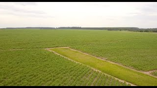

Canal Escoadouro - Passo a passo

**Disciplina: anejo e Conservação da gua e do Solo**

**Controle de Erosão Hídrica -**

| UNIVERSIDADE FEDERAL DE SERGIPE - UFS

**EXERCICIO CANAIS ESCOADOUROS**

Um certo produtor do Perimetro Irrigado da Ribeira, localizado na regiao Central do Estado, decidiu implantar um sistema de terraceamento em suas terras por razão de ocorrncia de erosão, porem foi, pelos acadmicos que finalizam a disciplina anejo e Conservaçao do Solo e da Agua, orientado que de acordo com as recomendações técnicas pertinentes, os terraços deveriam ser construidos em gradiente, com a previa construção de um canal escoadouro, e que o mesmo deveria levar em consideração as características de solo apresentada na Tabela 1, assim como as demais informações aqui apresentadas.

**TABELA 1** - Resultados da anlise física do Perfil de um PLANOSSOLOHÁPLICO Eutróficovértico

| ATRIBUTO |  | Horizontes |  |  |
| --- | --- | --- | --- | --- |
|  | Ap | E | EB | Bt |
| atéria Orgnica - dag/Kg | 3,6 | 1,3 | 0,8 | 0,8 |
| Areia Grossa - % | 2,0 | 1,0 | 1,0 | 1,0 |
| Areia Fina - % | 12,0 | 11,0 | 9,0 | 3,0 |
| Argila - % | 15,0 | 17,0 | 20,0 | 45,0 |
| Silte - % | 71,0 | 71,0 | 70,0 | 51,0 |

**INFORAÇOES ADICIONAIS:**

**Cultura: ilho em sucessão com feijão;**

**Solo: Consultar Tabela 1;**

**Declividade do terreno: 8%;**

**Declividade do canal: 6%;**

**Periodo de segurança: 5 anos**

**Precipitaçao media: 950mm;**

**Area: 400 x 200 m = 8,0 ha**

**O canal escoadouro sera revestido com gramíneas de densidade média e stand regular;**

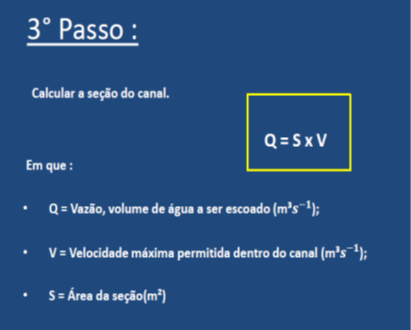

Cálculo de EH

**D= (EV/EH) X 100**

Obrigado!

Luiz Diego Vidal Santos

Universidade Estadual de Feira de Santana (UEFS)